# Classification Trees

Sean Schilk

11/31/2025

# Question 1

A classification tree is being considered to predict if an insurance policy will lapse. A random sample of 100 policies contains 30 that lapsed. You are considering two splits:

Split 1: One node has 20 observations with 12 lapses and one node has 80 observations with 18 lapses.

Split 2: One node has 10 observations with 8 lapses and one node has 90 observations with 22 lapses.

Using the Gini Index, which of the two splits results in better node purity? You must explain your reasoning.

```r
# No split Gini Index
(30/100)*(1 - 30/100) + (70/100)*(1-70/100)
```

```
## [1] 0.42
```

```r
# Split 1
Node_A1 <-  (12/20)*(1-12/20) + (8/20)*(1-8/20)
Node_A2 <- (18/80)*(1-18/80) + (62/80)*(1-62/80)
Weighted_Avg <- (.2*Node_A1) + (.8*Node_A2)
Weighted_Avg
```

```
## [1] 0.375
```

```r
# Split 2
Node_B1 <- (8/10)*(1-8/10) + (2/10)*(1-2/10)
Node_B2 <- (22/90)*(1-22/90) + (68/90)*(1-68/90)
WA2 <-  (.1*Node_B1) + (.9*Node_B2)
WA2
```

```
## [1] 0.3644444
```

Split 2 has the lowest Gini Index with 0.364, meaning it has the most pure nodes.

# Question 2

Read in the HW8data.csv. Call it heart. This data set has 303 observations and 14 variables. The response variable is called target. We are going to try to predict whether the person has heart disease based on certain characteristics (the 13 features).

```r
setwd("~/STA419/REDO/12.ClassificationTrees")

library(caret)
library(tidyverse)

heart <- read.csv("HW8data.csv")
str(heart)
```

```
## 'data.frame':    303 obs. of  14 variables:
##  $ age     : int  63 37 41 56 57 57 56 44 52 57 ...
##  $ sex     : int  1 1 0 1 0 1 0 1 1 1 ...
##  $ cp      : int  3 2 1 1 0 0 1 1 2 2 ...
##  $ trestbps: int  145 130 130 120 120 140 140 120 172 150 ...
##  $ chol    : int  233 250 204 236 354 192 294 263 199 168 ...
##  $ fbs     : int  1 0 0 0 0 0 0 0 1 0 ...
##  $ restecg : int  0 1 0 1 1 1 0 1 1 1 ...
##  $ thalach : int  150 187 172 178 163 148 153 173 162 174 ...
##  $ exang   : int  0 0 0 0 1 0 0 0 0 0 ...
##  $ oldpeak : num  2.3 3.5 1.4 0.8 0.6 0.4 1.3 0 0.5 1.6 ...
##  $ slope   : int  0 0 2 2 2 1 1 2 2 2 ...
##  $ ca      : int  0 0 0 0 0 0 0 0 0 0 ...
##  $ thal    : int  1 2 2 2 2 1 2 3 3 2 ...
##  $ target  : chr  "Yes" "Yes" "Yes" "Yes" ...
```

```r
table(heart$target)
```

```
##
##  No Yes
## 138 165
```

# a

Use 10-fold CV and set the seed to be 1. Fit an optimally pruned classification tree on the data set. What was your estimate of the test accuracy?

```r
set.seed(1)
fitControl <- trainControl(method = "cv", number = 10,
                           classProbs = TRUE)
model.tree <- train(target ~ .,
                    data = heart,
                    method = "rpart",
                    trControl = fitControl,
                    tuneLength = 10)

model.tree
```

```
## CART
##
## 303 samples
##  13 predictor
##   2 classes: 'No', 'Yes'
##
## No pre-processing
## Resampling: Cross-Validated (10 fold)
## Summary of sample sizes: 274, 272, 273, 272, 273, 272, ...
## Resampling results across tuning parameters:
##
##   cp          Accuracy   Kappa
##   0.00000000  0.7755877  0.5417225
##   0.05233494  0.8256174  0.6388807
##   0.10466989  0.7590286  0.5137660
##   0.15700483  0.7590286  0.5137660
##   0.20933977  0.7590286  0.5137660
##   0.26167472  0.7590286  0.5137660
##   0.31400966  0.7590286  0.5137660
##   0.36634461  0.7590286  0.5137660
##   0.41867955  0.7590286  0.5137660
##   0.47101449  0.6267186  0.2061386
##
## Accuracy was used to select the optimal model using the largest value.
## The final value used for the model was cp = 0.05233494.
```

We estimated the test accuracy to be 0.8256, with a cp = 0.0523.

# b

Plot the pruned tree. How many terminal nodes did you get?

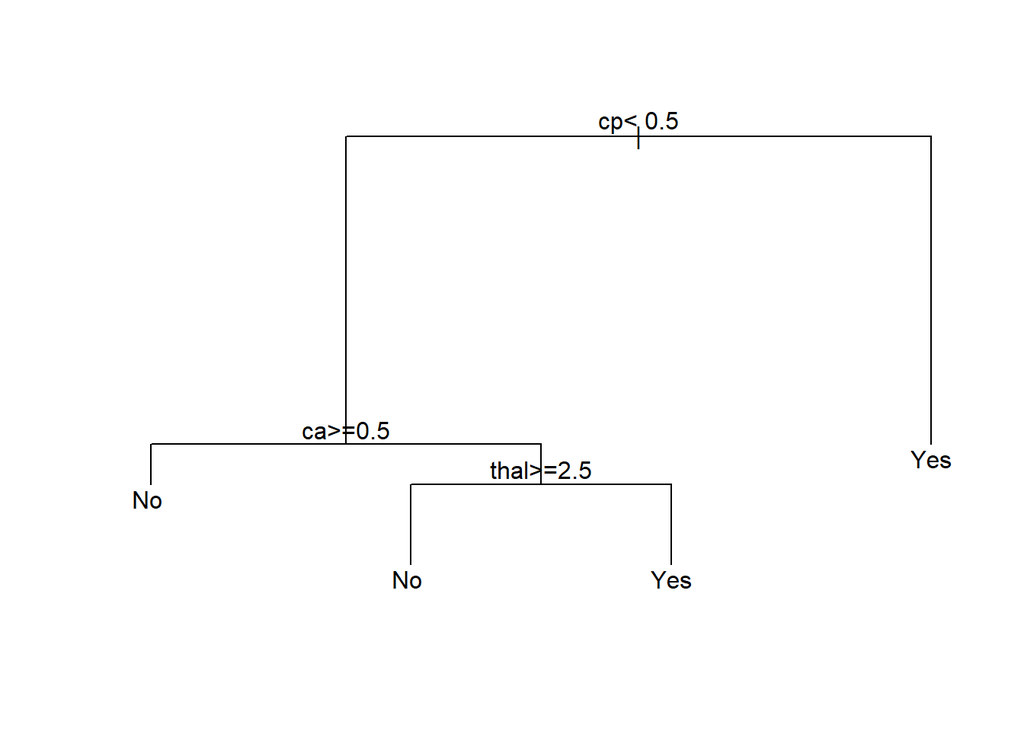

```r
par(xpd = NA)
plot(model.tree$finalModel)
text(model.tree$finalModel)
```

We got 4 terminal nodes.

# c

Use code similar to what’s found on slide 7 to verify you get the correct predictions in each node. How pure was each terminal node?

```r
#1st terminal node
heart %>%
  filter(cp < 0.5,
         ca >= 0.5) %>%
  group_by(target) %>%
  summarize(n = n())
```

| target | n |
| --- | --- |
| No | 73 |
| Yes | 5 |

```r
(73/78)*(1 - 73/78) + (5/78)*(1 - 5/78)
```

```
## [1] 0.1199869
```

```r
# 2nd
heart %>%
  filter(cp < 0.5,
         ca < 0.5,
         thal >=2.5) %>%
  group_by(target) %>%
  summarize(n = n())
```

| target | n |
| --- | --- |
| No | 22 |
| Yes | 5 |

```r
(22/27)*(1-22/27) + (5/27)*(1-5/27)
```

```
## [1] 0.3017833
```

```r
# 3rd
heart %>%
  filter(cp < 0.5,
         ca < 0.5,
         thal < 2.5) %>%
  group_by(target) %>%
  summarize(n = n())
```

| target | n |
| --- | --- |
| No | 9 |
| Yes | 29 |

```r
(9/38)*(1-9/38) + (29/38)*(1-29/38)
```

```
## [1] 0.3614958
```

```r
# 4th
heart %>%
  filter(cp >= 0.5,
         ) %>%
  group_by(target) %>%
  summarize(n = n())
```

| target | n |
| --- | --- |
| No | 34 |
| Yes | 126 |

```r
(34/160)*(1-34/160) + (126/160)*(1-126/160)
```

```
## [1] 0.3346875
```

The first node was the purest, with a Gini Index score of 0.12

# d

Explain why the variable and value were chosen to make the first decision. “Verify” this is the case by looking at our predictions if no decisions were made, a different value of chosen variable was used, and a different variable was chosen first (pick a value of that variable that was used in a later decision).

```r
table(heart$target)
```

```
##
##  No Yes
## 138 165
```

```r
# Gini Index with No splits
(138/303)*(1-138/303) + (165/303)*(1-165/303)
```

```
## [1] 0.4960298
```

```r
# 0.4960298

# First split from tree

heart %>%
  filter(cp < 0.5) %>%
  group_by(target) %>%
  summarize(n = n())
```

| target | n |
| --- | --- |
| No | 104 |
| Yes | 39 |

```r
(104/143)*(1-104/143) + (39/143)*(1-39/143)
```

```
## [1] 0.3966942
```

```r
heart %>%
  filter(cp >= 0.5) %>%
  group_by(target) %>%
  summarize(n = n())
```

| target | n |
| --- | --- |
| No | 34 |
| Yes | 126 |

```r
(34/160)*(1-34/160) + (126/160)*(1-126/160)
```

```
## [1] 0.3346875
```

```r
# Weighted Average of Split
(0.3966942 * 143/303) + (0.3346875 * 160/303)
```

```
## [1] 0.3639514
```

```r
# 0.3639514
# Notice GI score decreases here compared to no split (what we want!)

#Let's choose a different value to split at
heart %>%
  filter(cp < 2) %>%
  group_by(target) %>%
  summarize(n = n())
```

| target | n |
| --- | --- |
| No | 113 |
| Yes | 80 |

```r
(113/193)*(1-113/193) + (80/193)*(1-80/193)
```

```
## [1] 0.4853822
```

```r
heart %>%
  filter(cp >= 2) %>%
  group_by(target) %>%
  summarize(n = n())
```

| target | n |
| --- | --- |
| No | 25 |
| Yes | 85 |

```r
(25/110)*(1-25/110) + (85/110)*(1-85/110)
```

```
## [1] 0.3512397
```

```r
# Weighted Average
(0.4853822*193/303) + (0.3512397*110/303)
```

```
## [1] 0.4366836
```

```r
# = 0.4366836
# Notice the GI score rose when we changed the value where we split (we don't want this)

# Now let's split with a different variable
heart %>%
  filter(thal < 2.5) %>%
  group_by(target) %>%
  summarize(n = n())
```

| target | n |
| --- | --- |
| No | 49 |
| Yes | 137 |

```r
(49/186)*(1-49/186) + (137/186)*(1-137/186)
```

```
## [1] 0.3880795
```

```r
heart %>%
  filter(thal >= 2.5) %>%
  group_by(target) %>%
  summarize(n = n())
```

| target | n |
| --- | --- |
| No | 89 |
| Yes | 28 |

```r
(89/117)*(1-89/117) + (28/117)*(1-28/117)
```

```
## [1] 0.364088
```

```r
# Weighted Average
(0.3880795*186/303) + (0.364088*117/303)
```

```
## [1] 0.3788155
```

```r
#=0.3788155
# As we can see, this GI score also higher than our optimal split variable.
```

# e

Again using 10-fold CV and setting the seed to be 1, fit a random forest model trying 1, 2, 3, and 4 potential predictors at each split. What was your optimal estimate of the test accuracy? How many predictors at each split did this use?

```r
mtryGrid <- expand.grid(mtry = c(1, 2, 3, 4))

set.seed(1)
model.rf <- train(target ~ .,
                  data = heart,
                  method = "rf",
                  trControl = trainControl(method = "oob"),
                  tuneGrid = mtryGrid)

model.rf
```

```
## Random Forest
##
## 303 samples
##  13 predictor
##   2 classes: 'No', 'Yes'
##
## No pre-processing
## Resampling results across tuning parameters:
##
##   mtry  Accuracy   Kappa
##   1     0.8415842  0.6771874
##   2     0.8283828  0.6519549
##   3     0.8217822  0.6385686
##   4     0.8184818  0.6316557
##
## Accuracy was used to select the optimal model using the largest value.
## The final value used for the model was mtry = 1.
```

The optimal estimate of the test accuracy here is 0.8415842, with 1 predictor at each split

# f

What were the three most important predictors from the random forest model. Explain how these were chosen without having a single tree to look at.

```r
varImp(model.rf)
```

```
## rf variable importance
##
##          Overall
## cp       100.000
## thalach   87.706
## oldpeak   83.302
## ca        73.619
## thal      72.305
## age       64.390
## exang     52.605
## chol      50.989
## trestbps  47.034
## slope     40.576
## sex       25.810
## restecg    8.771
## fbs        0.000
```

The 3 most important predictors from the random forest model were, in order from most important to least: cp, thalach, oldpeak. We measured the amount of Gini Index we are saving here to find these.

# g

Again using 10-fold CV and setting the seed to be 1, fit a stochastic gradient boosting model using the default combination of the tuning parameters. What was the estimate of the test accuracy using the optimal model?

```r
set.seed(1)
model.gbm <- train(target ~ .,
                   data = heart,
                   method = "gbm",
                   trControl = fitControl)
model.gbm
```

```
## Stochastic Gradient Boosting
##
## 303 samples
##  13 predictor
##   2 classes: 'No', 'Yes'
##
## No pre-processing
## Resampling: Cross-Validated (10 fold)
## Summary of sample sizes: 274, 272, 273, 272, 273, 272, ...
## Resampling results across tuning parameters:
##
##   interaction.depth  n.trees  Accuracy   Kappa
##   1                   50      0.8495402  0.6945090
##   1                  100      0.8525436  0.7006513
##   1                  150      0.8226288  0.6394512
##   2                   50      0.8328587  0.6608634
##   2                  100      0.8191806  0.6333113
##   2                  150      0.8159548  0.6264099
##   3                   50      0.8327438  0.6611481
##   3                  100      0.8127364  0.6187150
##   3                  150      0.7996107  0.5931393
##
## Tuning parameter 'shrinkage' was held constant at a value of 0.1
##
## Tuning parameter 'n.minobsinnode' was held constant at a value of 10
## Accuracy was used to select the optimal model using the largest value.
## The final values used for the model were n.trees = 100, interaction.depth =
##  1, shrinkage = 0.1 and n.minobsinnode = 10.
```

the estimate of the test accuracy using the optimal model was 0.8525.

# h

Explain why the number of trees in stochastic gradient boosting was a tuning parameter but was not in a random forest model

This is because using too many trees can lead to overfitting in stochastic gradient boosting, unlike in random forests.